# Spearman Test Report

The **Spearman Test** is used to identify autocorrelation in a time series $y_{t}$. A **Significant Lag** is a number $i$ such that the correlation between $y_{t}$ and $y_{t-i}$ is statistically significant. The **Least Significant Lag** is the largest $i$ such that all $j \leq i$ are significant lags.

- Null Hypothesis: The greatest significant lag is $0$.
- Alternative Hypothesis: The greatest significant lag is greater than $0$.

To carry out the Spearman test, we use the following procedure:

1. Compute Spearman’s correlation coefficient $\rho_{i}$ for $y_{t}$ and $y_{t-i}$ for all $0 \leq i < n$.
2. Determine the $p$-value $p_{i}$ for each correlation coefficient $\rho _{i}$.
3. Iterate through $p_{i}$ to find the largest $i$ such that $p_{j} \leq \alpha$ for all $j \leq i$.
4. The value of $i$ found in (3) is the greatest significant lag at confidence level $\alpha$.

**Remark**: To compute the $p$-value of a correlation coefficient $\rho _{i}$, first compute:

$$t_{i}= \rho_{i} \sqrt{\frac{n-2}{1 - \rho _{i}^2}}$$

Then, the test statistic $t_{i}$ has the $t$-distribution with $n-2$ degrees of freedom.

For more information, see the following links:

- [Autocorrelation (Wikipedia)](https://en.wikipedia.org/wiki/Autocorrelation)
- [Spearman’s Correlation Coefficient (Wikipedia)](https://en.wikipedia.org/wiki/Spearman%27s_rank_correlation_coefficient)

## Results

### Code

```r
# Spearman test for serial correlation
#  - ams: A vector of annual maximum streamflow data
#  - alpha: The significance level as a floating point number
spearman_test <- function(ams, alpha = 0.05) {

    # Assign a variable to the number of data points for convenience
    n <- length(ams)

    # Compute the spearman rho-autocorrelation for a given lag
    rho_autocorrelation <- function(lag, ams) {
        ams_original <- ams[(lag + 1):length(ams)]
        ams_lagged <- ams[1:(length(ams) - lag)]
        cor.test(ams_original, ams_lagged, method="spearman", exact=FALSE)
    }

    # Find the lowest non-significant serial correlation lag
    rho <- numeric(n - 3)
    ps <- numeric(n - 3)

    for (i in 1:(n - 3)) {
        result <- rho_autocorrelation(i, ams)
        rho[i] = result$estimate
        ps[i] = result$p.value
    }

    least_lag <- which(ps > alpha)[1] - 1

    # Get a series of booleans for whether the serial correlation is significant
    sig <- (ps < alpha)

    # Print the results
    output <- ifelse(least_lag > 0, "evidence", "NO evidence")
    message(glue("\n\nThe Spearman test found a least significant lag of {least_lag}."))
    message(glue("Therefore, there is {output} of serial correlation."))

    # Return the results as a list
    mget(c("rho", "sig", "least_lag"))

}
```

### Statistics

The **Least Significant Lag** is: 16.

There is evidence of serial correlation in the data.

### Figure

```r
library(ggplot2)

# Source the plot theme (path is relative to /source)
source("helpers/plot-theme.R")


# Plot the results of the Mann-Whitney-Pettitt test for abrupt changes in the mean
spearman_plot <- function(df, results, show_trend) {

    # Load the results of the test into the environment
    list2env(results, envir = environment())

    # Add u_t to df and create change point df (if change point is significant)
    rho_df <- data.frame(
        lag = 1:length(rho),
        rho = rho,
        sig = sig
    )

    # First subplot: Spearman's Rho Autocorrelation
    p1 <- ggplot(rho_df, aes(x = lag, y = rho)) +
        geom_segment(aes(x = lag, xend = lag, y = 0, yend = rho)) +
        geom_point(
            aes(fill = sig),
            shape = 21,
            size = 3,
            stroke = 1.2
        ) +
        labs(
            title = "Spearman's rho Autocorrelation",
            x = "Lag",
            y = "Spearman's rho",
            fill = "Legend"
        ) +
        scale_fill_manual(
            values = c(`TRUE` = "black", `FALSE` = "white"),
            labels = c("No Serial Correlation", "Serial Correlation"),
        )

    # Return the plot with added theme
    add_theme(p1)

}
```

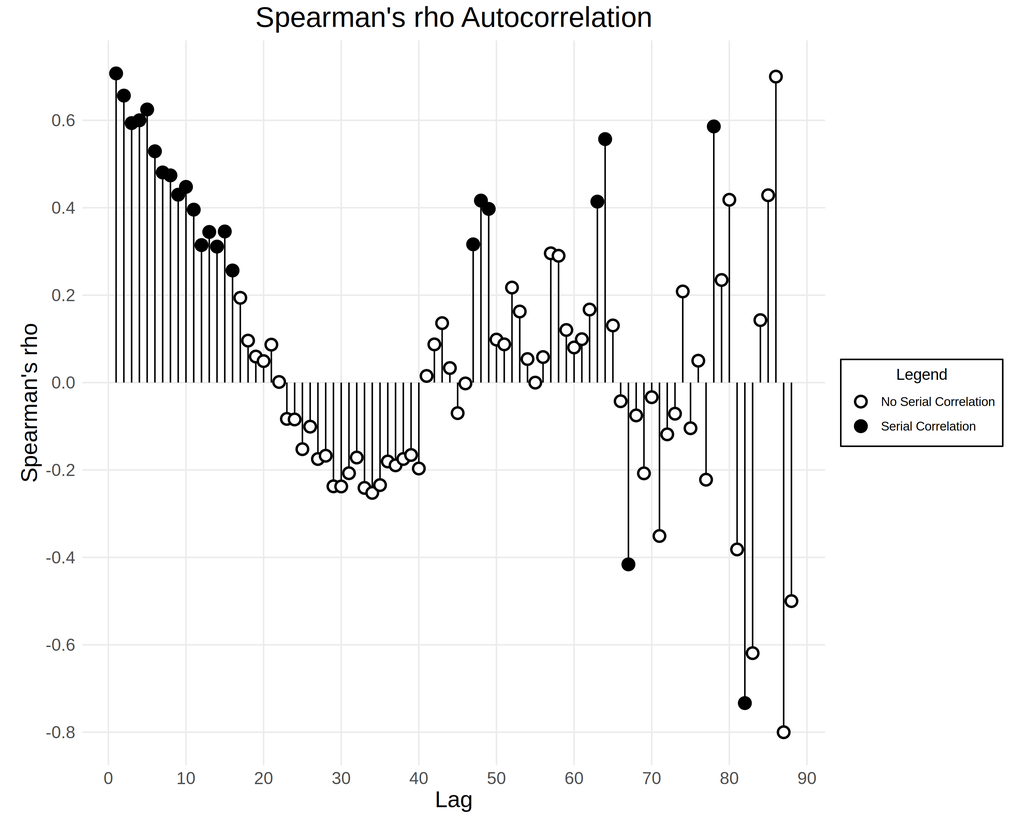